# Qualitative Modeling

## Incorporating Interaction Terms and Transformations

- From before, we saw that `charges` was a predictor that was nicely transformed with a log transform
- We will use the `age` variable interacting with several other variables such as `meanbp`, `dementia`,`surv2m`, and `surv6m`

```r
multi_logit_enhanced <- multinom(y ~ death +
                                   hospdead + slos + d_time + edu + scoma + log(charges + 1) + totcst + avtisst + sps + aps + surv2m + surv6m
                                 + hday + diabetes + dementia + prg2m + prg6m + dnrday + meanbp + wblc + hrt + resp + temp + crea + sod + adlsc + sex_male +
                                   num_co_1 + num_co_2 + num_co_3 + num_co_4 + num_co_5 + num_co_6 + num_co_7 +
                                   race_black + race_hispanic + race_other + race_white + `dnr_dnr_before_sadm` + `dnr_no_dnr` + sfdm2_adl_4_5_if_sur +
                                   sfdm2_coma_or_intub + sfdm2_no_m2_and_sip_pres + sfdm2_sip_30 +
                                   age * meanbp + age * dementia + age * surv2m + age * surv6m + age * prg2m + age * prg6m

                                   , data = train_data)
pred_multi_logit_enhanced <- predict(multi_logit_enhanced, newdata = test_data)
```

```r
y_test <- test_data$y

multi_logit_e_error <- sum(y_test != pred_multi_logit_enhanced) / length(y_test)

print(multi_logit_e_error)
```

```
## [1] 0.1138716
```

The enhanced multinomial model performed worse.

#### Confusion Matrix

```r
cm_e_mlogit <- confusionMatrix(reference = factor(y_test), data = factor(pred_multi_logit_enhanced))
cm_e_mlogit
```

```
## Confusion Matrix and Statistics
##
##                     Reference
## Prediction           ARF/MOSF Cancer Coma COPD/CHF/Cirrhosis
##   ARF/MOSF                221      3   13                 19
##   Cancer                    1     64    0                  3
##   Coma                      5      0   19                  0
##   COPD/CHF/Cirrhosis        9      2    0                124
##
## Overall Statistics
##
##                Accuracy : 0.8861
##                  95% CI : (0.8544, 0.9131)
##     No Information Rate : 0.4886
##     P-Value [Acc > NIR] : < 2.2e-16
##
##                   Kappa : 0.8201
##
##  Mcnemar's Test P-Value : NA
##
## Statistics by Class:
##
##                      Class: ARF/MOSF Class: Cancer Class: Coma
## Sensitivity                   0.9364        0.9275     0.59375
## Specificity                   0.8583        0.9903     0.98891
## Pos Pred Value                0.8633        0.9412     0.79167
## Neg Pred Value                0.9339        0.9880     0.97168
## Prevalence                    0.4886        0.1429     0.06625
## Detection Rate                0.4576        0.1325     0.03934
## Detection Prevalence          0.5300        0.1408     0.04969
## Balanced Accuracy             0.8974        0.9589     0.79133
##                      Class: COPD/CHF/Cirrhosis
## Sensitivity                             0.8493
## Specificity                             0.9674
## Pos Pred Value                          0.9185
## Neg Pred Value                          0.9368
## Prevalence                              0.3023
## Detection Rate                          0.2567
## Detection Prevalence                    0.2795
## Balanced Accuracy                       0.9083
```

```r
cm_e_mlogit_table <- cm_e_mlogit$table

tpr <- fpr <- tnr <- fnr <- numeric(4)

for (i in 1:4) {
  tp <- cm_e_mlogit_table[i, i]
  fn <- sum(cm_e_mlogit_table[i,]) - tp
  fp <- sum(cm_e_mlogit_table[,i]) - tp
  tn <- sum(cm_e_mlogit_table) - (tp + fn + fp)

  tpr[i] <- tp / (tp + fn)  # True Positive Rate
  fpr[i] <- fp / (fp + tn)  # False Positive Rate
  tnr[i] <- tn / (tn + fp)  # True Negative Rate
  fnr[i] <- fn / (fn + tp)  # False Negative Rate
}

# Print the results
cat("True Positive Rates (TPR):", tpr, "\n",
    "False Positive Rates (FPR):", fpr, "\n",
    "True Negative Rates (TNR):", tnr, "\n",
    "False Negative Rates (FNR):", fnr, "\n")
```

```
## True Positive Rates (TPR): 0.8632812 0.9411765 0.7916667 0.9185185
##  False Positive Rates (FPR): 0.0660793 0.01204819 0.02832244 0.06321839
##  True Negative Rates (TNR): 0.9339207 0.9879518 0.9716776 0.9367816
##  False Negative Rates (FNR): 0.1367188 0.05882353 0.2083333 0.08148148
```

Comparing the two confusion matrices from the multinomial logistic models, the first matrix, representing the base model, shows an overall accuracy of 90.48%. The second matrix, which includes a transformed variable and interaction terms, shows a slightly decreased overall accuracy of 88.61% suggesting that the modifications slightly reduced the model’s effectiveness. The first model has notably higher balanced accuracy across all conditions except for Cancer, where the second model shows a slight improvement. The changes in the second model, particularly in sensitivity for ARF/MOSF and specificity for COPD/CHF/cirrhosis, suggest that while the interaction terms and transformation might have improved the model’s fit for Cancer, it may have compromised its general predictive ability slightly for other conditions.

# Decision Tree

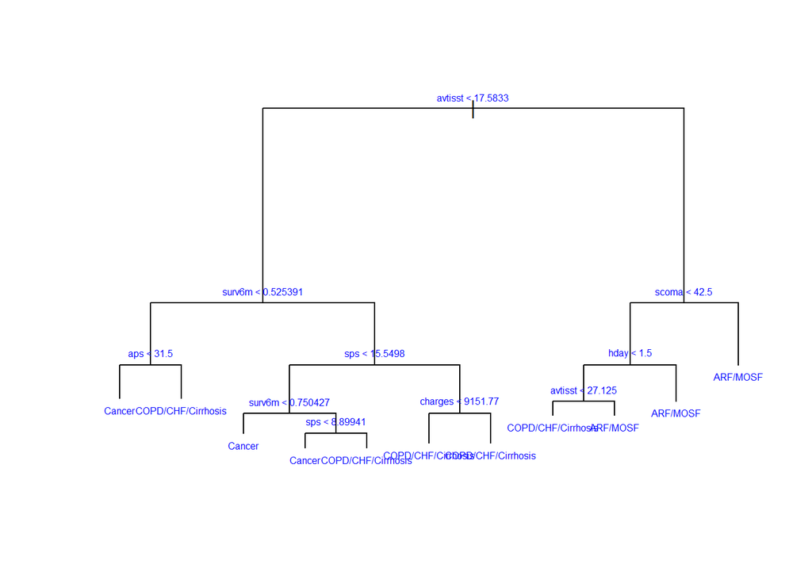

```r
tree_train <- tree::tree(y ~ ., data = train_data)

plot(tree_train)
text(tree_train, cex = 0.5, col = "blue")
```

```r
tree_train_cv <- tree::cv.tree(tree_train)

tree_train_cv
```

```
## $size
##  [1] 11 10  9  8  7  6  5  4  3  2  1
##
## $dev
##  [1]  6047.317  6279.584  6279.584  6505.807  6860.228  7103.325  7197.097
##  [8]  7691.729  8683.992  8683.992 10200.684
##
## $k
##  [1]      -Inf  120.0193  121.9349  172.3849  254.0631  281.0034  306.2618
##  [8]  406.7138  525.6608  528.0804 1643.9645
##
## $method
## [1] "deviance"
##
## attr(,"class")
## [1] "prune"         "tree.sequence"
```

# Bagging

```r
suppressMessages(library(randomForest))

p <- ncol(train_data) - 1

n_trees <- 1000

set.seed(32)

bag_train <-
  randomForest(
    y ~ .,
    data = train_data,
    ntree = n_trees,
    mtry = p,
    keep.forest = TRUE,
    importance = TRUE
  )
```

```r
bag_train
```

```
##
## Call:
##  randomForest(formula = y ~ ., data = train_data, ntree = n_trees,      mtry = p, keep.forest = TRUE, importance = TRUE)
##                Type of random forest: classification
##                      Number of trees: 1000
## No. of variables tried at each split: 47
##
##         OOB estimate of  error rate: 15.33%
## Confusion matrix:
##                    ARF/MOSF Cancer Coma COPD/CHF/Cirrhosis class.error
## ARF/MOSF               1829     14   40                154   0.1021109
## Cancer                   12    596    6                 26   0.0687500
## Coma                    107      4  148                  2   0.4329502
## COPD/CHF/Cirrhosis      267     30    5               1111   0.2137297
```

Bagging resulted in a 0.1533 OOB error rate

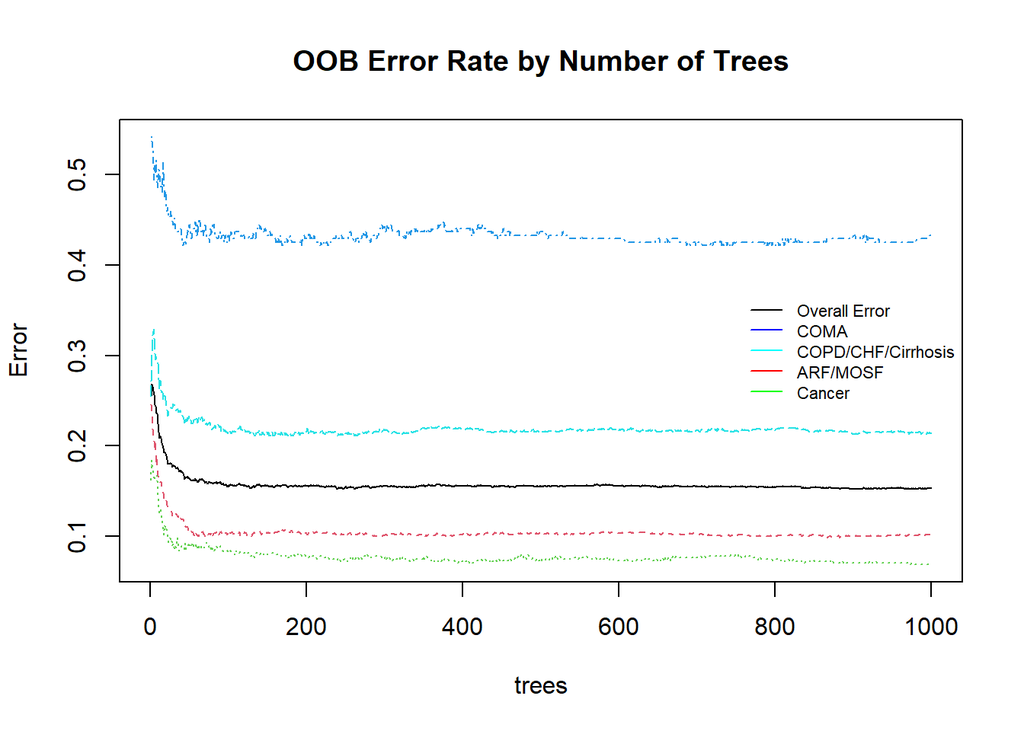

```r
plot(bag_train, main = "OOB Error Rate by Number of Trees")
# par(xpd=FALSE)
legend("right",  # positions the legend in the top right corner of the plot
       legend=c("Overall Error", "COMA", "COPD/CHF/Cirrhosis", "ARF/MOSF", "Cancer"),  # names of the lines
       col=c("black", "blue", "cyan", "red", "green"),  # colors must match those in the plot
       lty=1, bty = "n", cex = 0.7)
```

## Feature Importance

```r
importance(bag_train)
```

```
##                              ARF/MOSF      Cancer          Coma
## age                       21.35702009  39.2588993   3.330755318
## death                     16.11752464   9.4967323   3.024895254
## hospdead                   5.21612985   2.6774955   1.410272634
## slos                      24.52385123   6.7422673   5.387393167
## d_time                    24.31839737  24.5211374   5.718265049
## edu                        1.44964200   3.4397750  -4.010690654
## scoma                     16.59523199  94.2327181 169.504366031
## charges                   57.14385045  35.2797445   7.175145347
## totcst                    37.13418248  15.6348514   5.412047169
## avtisst                   67.85964351  36.3140537  15.132325033
## sps                       51.80259787  94.5339477   7.411236925
## aps                       70.35940922  82.7359393 -10.409516397
## surv2m                    34.47997161  34.6717846  39.830945839
## surv6m                    63.39290858 206.0327801  42.889642790
## hday                     103.25931122  62.6848208  -3.185617677
## diabetes                  -0.25480972   5.8337149   1.270456371
## dementia                   1.84614489  14.2408752   2.243107880
## prg2m                     22.36995348   5.6427709  15.253575681
## prg6m                     30.29557236  12.6945061  10.218379372
## dnrday                     5.75015962   8.2397343   2.362375685
## meanbp                     0.30385728   5.1505438   4.337768956
## wblc                      -4.54848477   1.8641905   8.957515062
## hrt                        3.09873850   5.7140670   0.037523438
## resp                      -2.76833947   8.5179939  -1.668066052
## temp                       3.78645575   3.6530867   1.191504975
## crea                       8.68596870   7.0653307  -0.052443992
## sod                       -1.25880109  11.7578931   3.851475355
## adlsc                      9.00926250   6.7080633  -3.780161298
## sex_male                   0.53579943   0.6505953  -1.580459062
## num_co_1                  -0.07129973  38.5928821  -0.822944144
## num_co_2                  -1.12651985   3.1515898   4.430325023
## num_co_3                  18.05120850   8.1293003  11.337330859
## num_co_4                  17.54541330  13.6350843   3.201051409
## num_co_5                  18.19947171   8.1082247   4.124178656
## num_co_6                   5.26622024  12.7097097   0.000000000
## num_co_7                  25.15165280   1.4150369   1.000500375
## num_co_8                   0.00000000   0.0000000   0.000000000
## race_black                 0.58827206  -1.0205322   0.001615984
## race_hispanic              2.48952397  -0.3140040   0.260619518
```

[output cut: 89 more lines]

```
## num_co_4                         9.147474
## num_co_5                         6.294092
## num_co_6                         3.310355
## num_co_7                         4.965774
## num_co_8                         0.000000
## race_black                       3.473382
## race_hispanic                    2.863074
## race_other                       2.609480
## race_white                       3.470086
## dnr_dnr_before_sadm              1.093586
## dnr_no_dnr                       3.390762
## sfdm2_adl_4_5_if_sur             4.478788
## sfdm2_coma_or_intub              0.797286
## sfdm2_no_m2_and_sip_pres         3.826210
## sfdm2_sip_30                     3.892642
```

In the bagging model, the variables *scoma* and *surv6m* stand out as the most critical predictors. *Scoma*, with a `MeanDecreaseAccuracy` of 144.187 and a `MeanDecreaseGini` of 168.973, is paramount, especially for predicting outcomes in the “Coma” class. Its high importance scores signify its strong influence on classification decisions, indicating that changes in coma scores significantly affect the model’s ability to accurately classify patient conditions. This suggests that coma status is a crucial clinical indicator in the prognosis and categorization of patient health states, particularly in severe cases.

Similarly, *surv6m*, reflecting six-month survival probability, shows extremely high importance with a `MeanDecreaseAccuracy` of 214.077 and a `MeanDecreaseGini` of 412.385. Its prominence is especially noted in predicting outcomes for “Cancer” and “COPD/CHF/Cirrhosis” classes. High importance values in both accuracy and Gini indices underline its role in long-term survival predictions, implying that survival probabilities heavily influence the model’s predictions across these critical health conditions. This underscores the variable’s utility in assessing patient prognosis and informing healthcare strategies focused on improving survival rates.

```r
pred_bag <- predict(bag_train, newdata = test_data)

bag_error <- mean(y_test != pred_bag)

print(bag_error)
```

```
## [1] 0.1614907
```

#### Confusion Matrix

```r
cm_bag <- confusionMatrix(reference = factor(y_test), data = factor(pred_bag))
cm_bag
```

```
## Confusion Matrix and Statistics
##
##                     Reference
## Prediction           ARF/MOSF Cancer Coma COPD/CHF/Cirrhosis
##   ARF/MOSF                217      3   17                 27
##   Cancer                    2     62    0                  7
##   Coma                      3      0   15                  1
##   COPD/CHF/Cirrhosis       14      4    0                111
##
## Overall Statistics
##
##                Accuracy : 0.8385
##                  95% CI : (0.8026, 0.8702)
##     No Information Rate : 0.4886
##     P-Value [Acc > NIR] : < 2.2e-16
##
##                   Kappa : 0.7431
##
##  Mcnemar's Test P-Value : NA
##
## Statistics by Class:
##
##                      Class: ARF/MOSF Class: Cancer Class: Coma
## Sensitivity                   0.9195        0.8986     0.46875
## Specificity                   0.8097        0.9783     0.99113
## Pos Pred Value                0.8220        0.8732     0.78947
## Neg Pred Value                0.9132        0.9830     0.96336
## Prevalence                    0.4886        0.1429     0.06625
## Detection Rate                0.4493        0.1284     0.03106
## Detection Prevalence          0.5466        0.1470     0.03934
## Balanced Accuracy             0.8646        0.9384     0.72994
##                      Class: COPD/CHF/Cirrhosis
## Sensitivity                             0.7603
## Specificity                             0.9466
## Pos Pred Value                          0.8605
## Neg Pred Value                          0.9011
## Prevalence                              0.3023
## Detection Rate                          0.2298
## Detection Prevalence                    0.2671
## Balanced Accuracy                       0.8534
```

```r
cm_bag_table <- cm_bag$table

tpr <- fpr <- tnr <- fnr <- numeric(4)

for (i in 1:4) {
  tp <- cm_bag_table[i, i]
  fn <- sum(cm_bag_table[i,]) - tp
  fp <- sum(cm_bag_table[,i]) - tp
  tn <- sum(cm_bag_table) - (tp + fn + fp)

  tpr[i] <- tp / (tp + fn)  # True Positive Rate
  fpr[i] <- fp / (fp + tn)  # False Positive Rate
  tnr[i] <- tn / (tn + fp)  # True Negative Rate
  fnr[i] <- fn / (fn + tp)  # False Negative Rate
}

# Print the results
cat("True Positive Rates (TPR):", tpr, "\n",
    "False Positive Rates (FPR):", fpr, "\n",
    "True Negative Rates (TNR):", tnr, "\n",
    "False Negative Rates (FNR):", fnr, "\n")
```

```
## True Positive Rates (TPR): 0.8219697 0.8732394 0.7894737 0.8604651
##  False Positive Rates (FPR): 0.08675799 0.01699029 0.03663793 0.09887006
##  True Negative Rates (TNR): 0.913242 0.9830097 0.9633621 0.9011299
##  False Negative Rates (FNR): 0.1780303 0.1267606 0.2105263 0.1395349
```

The confusion matrix for the bagging models hows the performance, achieving an overall accuracy of 83.85%. The model performs best in identifying Cancer with high sensitivity (89.86%) and specificity (97.83%), reflected in its high balanced accuracy of 93.84%. ARF/MOSF also shows solid performance with a sensitivity of 91.95% but has lower specificity (80.97%). Coma detection is notably less effective, with the lowest sensitivity (46.875%) and balanced accuracy (72.994%), indicating significant challenges in correctly predicting this condition. COPD/CHF/cirrhosis has moderate sensitivity and specificity, with noticeable misclassifications as ARF/MOSF. Overall, while the model effectively identifies Cancer, its performance is uneven across other conditions, particularly struggling with Coma.

# Random Forests

```r
set.seed(32)

rf_train <-
  randomForest(y ~ .,
               data = train_data,
               ntree = n_trees)

rf_train
```

```
##
## Call:
##  randomForest(formula = y ~ ., data = train_data, ntree = n_trees)
##                Type of random forest: classification
##                      Number of trees: 1000
## No. of variables tried at each split: 6
##
##         OOB estimate of  error rate: 17.79%
## Confusion matrix:
##                    ARF/MOSF Cancer Coma COPD/CHF/Cirrhosis class.error
## ARF/MOSF               1824     14   20                179   0.1045655
## Cancer                   24    576    5                 35   0.1000000
## Coma                    127      7  123                  4   0.5287356
## COPD/CHF/Cirrhosis      331     25    3               1054   0.2540694
```

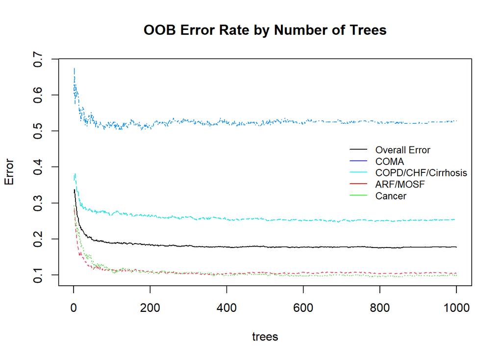

```r
plot(rf_train, main = "OOB Error Rate by Number of Trees")
# par(xpd=FALSE)
legend("right",  # positions the legend in the top right corner of the plot
       legend=c("Overall Error", "COMA", "COPD/CHF/Cirrhosis", "ARF/MOSF", "Cancer"),  # names of the lines
       col=c("black", "blue", "cyan", "red", "green"),  # colors must match those in the plot
       lty=1, bty = "n", cex = 0.8)
```

The random forest model has a worse OOB performance than the bagging model.

```r
importance(rf_train)
```

```
##                          MeanDecreaseGini
## age                          8.876032e+01
## death                        2.305535e+01
## hospdead                     1.911643e+01
## slos                         7.146664e+01
## d_time                       8.643899e+01
## edu                          4.246565e+01
## scoma                        1.019470e+02
## charges                      2.079126e+02
## totcst                       1.944392e+02
## avtisst                      2.241924e+02
## sps                          1.815078e+02
## aps                          1.844804e+02
## surv2m                       1.759495e+02
## surv6m                       2.348320e+02
## hday                         1.425104e+02
## diabetes                     1.091267e+01
## dementia                     5.310906e+00
## prg2m                        5.603541e+01
## prg6m                        7.116117e+01
## dnrday                       6.631909e+01
## meanbp                       5.973993e+01
## wblc                         6.194219e+01
## hrt                          5.425957e+01
## resp                         5.042847e+01
## temp                         6.223873e+01
## crea                         5.514691e+01
## sod                          5.285707e+01
## adlsc                        3.883296e+01
## sex_male                     1.132449e+01
## num_co_1                     7.406135e+01
## num_co_2                     1.230222e+01
## num_co_3                     1.923284e+01
## num_co_4                     1.358585e+01
## num_co_5                     7.347470e+00
## num_co_6                     2.567443e+00
## num_co_7                     3.078488e+00
## num_co_8                     8.888889e-04
## race_black                   8.161984e+00
## race_hispanic                3.438966e+00
## race_other                   1.600506e+00
## race_white                   8.019778e+00
## dnr_dnr_before_sadm          3.031679e+00
## dnr_no_dnr                   8.937370e+00
## sfdm2_adl_4_5_if_sur         8.285262e+00
## sfdm2_coma_or_intub          4.753366e-01
## sfdm2_no_m2_and_sip_pres     1.014795e+01
## sfdm2_sip_30                 5.084486e+00
```

```r
pred_rf <- predict(rf_train, newdata = test_data)

rf_error <- mean(y_test != pred_rf)

print(rf_error)
```

```
## [1] 0.2070393
```

#### Confusion Matrix

```r
cm_rf <- confusionMatrix(reference = factor(y_test), data = factor(pred_rf))
cm_rf
```

```
## Confusion Matrix and Statistics
##
##                     Reference
## Prediction           ARF/MOSF Cancer Coma COPD/CHF/Cirrhosis
##   ARF/MOSF                213      6   23                 37
##   Cancer                    1     58    0                  5
##   Coma                      1      0    9                  1
##   COPD/CHF/Cirrhosis       21      5    0                103
##
## Overall Statistics
##
##                Accuracy : 0.793
##                  95% CI : (0.754, 0.8282)
##     No Information Rate : 0.4886
##     P-Value [Acc > NIR] : < 2.2e-16
##
##                   Kappa : 0.6642
##
##  Mcnemar's Test P-Value : NA
##
## Statistics by Class:
##
##                      Class: ARF/MOSF Class: Cancer Class: Coma
## Sensitivity                   0.9025        0.8406     0.28125
## Specificity                   0.7328        0.9855     0.99557
## Pos Pred Value                0.7634        0.9063     0.81818
## Neg Pred Value                0.8873        0.9737     0.95127
## Prevalence                    0.4886        0.1429     0.06625
## Detection Rate                0.4410        0.1201     0.01863
## Detection Prevalence          0.5776        0.1325     0.02277
## Balanced Accuracy             0.8177        0.9130     0.63841
##                      Class: COPD/CHF/Cirrhosis
## Sensitivity                             0.7055
## Specificity                             0.9228
## Pos Pred Value                          0.7984
## Neg Pred Value                          0.8785
## Prevalence                              0.3023
## Detection Rate                          0.2133
## Detection Prevalence                    0.2671
## Balanced Accuracy                       0.8142
```

```r
cm_rf_table <- cm_rf$table

tpr <- fpr <- tnr <- fnr <- numeric(4)

for (i in 1:4) {
  tp <- cm_rf_table[i, i]
  fn <- sum(cm_rf_table[i,]) - tp
  fp <- sum(cm_rf_table[,i]) - tp
  tn <- sum(cm_rf_table) - (tp + fn + fp)

  tpr[i] <- tp / (tp + fn)  # True Positive Rate
  fpr[i] <- fp / (fp + tn)  # False Positive Rate
  tnr[i] <- tn / (tn + fp)  # True Negative Rate
  fnr[i] <- fn / (fn + tp)  # False Negative Rate
}

# Print the results
cat("True Positive Rates (TPR):", tpr, "\n",
    "False Positive Rates (FPR):", fpr, "\n",
    "True Negative Rates (TNR):", tnr, "\n",
    "False Negative Rates (FNR):", fnr, "\n")
```

```
## True Positive Rates (TPR): 0.7634409 0.90625 0.8181818 0.7984496
##  False Positive Rates (FPR): 0.1127451 0.02625298 0.04872881 0.1214689
##  True Negative Rates (TNR): 0.8872549 0.973747 0.9512712 0.8785311
##  False Negative Rates (FNR): 0.2365591 0.09375 0.1818182 0.2015504
```

The confusion matrix reflects the performance of our Random Forest model with an overall accuracy of 79.3%. The model excels at detecting Cancer, achieving high sensitivity (84.06%) and specificity (98.55%), resulting in a balanced accuracy of 91.30%. However, it underperforms in detecting Coma, evidenced by low sensitivity (28.125%) but very high specificity (99.557%), suggesting it rarely mislabels other conditions as Coma but struggles to identify actual cases of Coma. The model demonstrates moderate effectiveness for ARF/MOSF and COPD/CHF/cirrhosis, with some issues in overclassifying COPD/CHF/cirrhosis as ARF/MOSF, indicating potential areas for model refinement.

# Boosting

These variables have near zero variance which adds noise and could potentially harm the performance of the model, especially boosting. For boosting, we will remove these features that have near zero variance

```r
nzv <- nearZeroVar(train_data)

train_data_non0var <- train_data[, -nzv]
```

I will utilize parallel processing to speed up the training process

```r
set.seed(32)
#library(gbm3)

library(doParallel)

numCores <- detectCores() - 1
cl <- makeCluster(numCores)
registerDoParallel(cl)
n_trees <- 1000

boost_grid <- expand.grid(interaction.depth = c(2, 4, 8), # 4 is used in textbook
                          n.trees = n_trees,
                          shrinkage = c(0.4, 0.2, 0.1, 0.01, 0.001), # small number of cv showed 0.10 best so throwing in 0.2 to see if it'll decrease
                          n.minobsinnode = 20 # min observations in each node
                          )

fitControl <- trainControl(
  method = "cv",
  number = 5, # 5 fold
  allowParallel = TRUE # parallel processing
  )

boost_model <- caret::train(y ~ ., data = train_data_non0var,
                     method = "gbm",
                     trControl = fitControl,
                     tuneGrid = boost_grid,
                     verbose = FALSE)

stopCluster(cl)
registerDoSEQ()
```

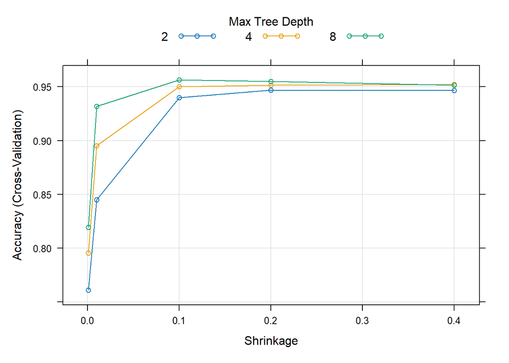

```r
boost_plot <- plot(boost_model)
boost_plot
```

```r
boost_model
```

```
## Stochastic Gradient Boosting
##
## 4351 samples
##   38 predictor
##    4 classes: 'ARF/MOSF', 'Cancer', 'Coma', 'COPD/CHF/Cirrhosis'
##
## No pre-processing
## Resampling: Cross-Validated (5 fold)
## Summary of sample sizes: 3481, 3481, 3482, 3480, 3480
## Resampling results across tuning parameters:
##
##   shrinkage  interaction.depth  Accuracy   Kappa
##   0.001      2                  0.7609785  0.6179048
##   0.001      4                  0.7954550  0.6771787
##   0.001      8                  0.8193564  0.7161836
##   0.010      2                  0.8450972  0.7577836
##   0.010      4                  0.8951990  0.8365161
##   0.010      8                  0.9319693  0.8939380
##   0.100      2                  0.9400129  0.9067274
##   0.100      4                  0.9501255  0.9224099
##   0.100      8                  0.9563297  0.9321586
##   0.200      2                  0.9471378  0.9178497
##   0.200      4                  0.9517331  0.9250055
##   0.200      8                  0.9549515  0.9299951
##   0.400      2                  0.9466788  0.9173008
##   0.400      4                  0.9521926  0.9257937
##   0.400      8                  0.9515013  0.9245450
##
## Tuning parameter 'n.trees' was held constant at a value of 1000
##
## Tuning parameter 'n.minobsinnode' was held constant at a value of 20
## Accuracy was used to select the optimal model using the largest value.
## The final values used for the model were n.trees = 1000, interaction.depth =
##  8, shrinkage = 0.1 and n.minobsinnode = 20.
```

```r
pred_boost <- predict(boost_model, newdata = test_data_non0var)

boost_error <- mean(y_test != pred_boost)

print(boost_error)
```

```
## [1] 0.04347826
```

#### Confusion Matrix

```r
cm_boost <- confusionMatrix(reference = factor(y_test), data = factor(pred_boost))
cm_boost
```

```
## Confusion Matrix and Statistics
##
##                     Reference
## Prediction           ARF/MOSF Cancer Coma COPD/CHF/Cirrhosis
##   ARF/MOSF                233      2   12                  1
##   Cancer                    0     65    0                  0
##   Coma                      3      0   19                  0
##   COPD/CHF/Cirrhosis        0      2    1                145
##
## Overall Statistics
##
##                Accuracy : 0.9565
##                  95% CI : (0.9343, 0.9729)
##     No Information Rate : 0.4886
##     P-Value [Acc > NIR] : < 2.2e-16
##
##                   Kappa : 0.9314
##
##  Mcnemar's Test P-Value : NA
##
## Statistics by Class:
##
##                      Class: ARF/MOSF Class: Cancer Class: Coma
## Sensitivity                   0.9873        0.9420     0.59375
## Specificity                   0.9393        1.0000     0.99335
## Pos Pred Value                0.9395        1.0000     0.86364
## Neg Pred Value                0.9872        0.9904     0.97180
## Prevalence                    0.4886        0.1429     0.06625
## Detection Rate                0.4824        0.1346     0.03934
## Detection Prevalence          0.5135        0.1346     0.04555
## Balanced Accuracy             0.9633        0.9710     0.79355
##                      Class: COPD/CHF/Cirrhosis
## Sensitivity                             0.9932
## Specificity                             0.9911
## Pos Pred Value                          0.9797
## Neg Pred Value                          0.9970
## Prevalence                              0.3023
## Detection Rate                          0.3002
## Detection Prevalence                    0.3064
## Balanced Accuracy                       0.9921
```

```r
cm_boost_table <- cm_boost$table

tpr <- fpr <- tnr <- fnr <- numeric(4)

for (i in 1:4) {
  tp <- cm_boost_table[i, i]
  fn <- sum(cm_boost_table[i,]) - tp
  fp <- sum(cm_boost_table[,i]) - tp
  tn <- sum(cm_boost_table) - (tp + fn + fp)

  tpr[i] <- tp / (tp + fn)  # True Positive Rate
  fpr[i] <- fp / (fp + tn)  # False Positive Rate
  tnr[i] <- tn / (tn + fp)  # True Negative Rate
  fnr[i] <- fn / (fn + tp)  # False Negative Rate
}

# Print the results
cat("True Positive Rates (TPR):", tpr, "\n",
    "False Positive Rates (FPR):", fpr, "\n",
    "True Negative Rates (TNR):", tnr, "\n",
    "False Negative Rates (FNR):", fnr, "\n")
```

```
## True Positive Rates (TPR): 0.9395161 1 0.8636364 0.9797297
##  False Positive Rates (FPR): 0.01276596 0.009569378 0.02819957 0.002985075
##  True Negative Rates (TNR): 0.987234 0.9904306 0.9718004 0.9970149
##  False Negative Rates (FNR): 0.06048387 0 0.1363636 0.02027027
```

# Extreme Gradient Boosting

We decided to incorporate XGBoost into our analysis, despite it not being a mandated part of the curriculum. This decision was driven by XGBoost’s prominent standing in the field of data science, particularly for its exceptional performance with tabular datasets. XGBoost, an extension of the gradient boosting framework we covered in class, is renowned for its efficiency and capability in handling various types of predictive modeling challenges. This advanced algorithm enhances traditional boosting techniques through its sophisticated engineering, which includes handling sparse data, tree pruning, and regularization, among other features. Integrating XGBoost allowed us to explore its powerful ensemble learning capabilities and provided a deeper understanding of its practical applications and superiority in predictive accuracy, making it a valuable addition to the project and an insightful extension of the concepts learned in class.

For boosting we will utilize extreme gradient boosting from the `xgboost` library

```r
suppressMessages(library(xgboost))

train_data_numeric_y <- train_data
train_data_numeric_y$y <- as.integer(train_data$y) - 1

test_data_numeric_y <- test_data
test_data_numeric_y$y <- as.integer(test_data$y) - 1

#train_data$y_integer <- as.integer(train_data$y) - 1

X_train = as.matrix(train_data_numeric_y[, -1])
y_train = as.matrix(train_data_numeric_y[, 1])

X_test = as.matrix(test_data_numeric_y[, -1])
y_test = as.matrix(test_data_numeric_y[, 1])

# xgboost matrix type
xgb_train <- xgb.DMatrix(data = X_train, label = y_train)
xgb_test <- xgb.DMatrix(data = X_test, label = y_test)
```

We will use cross validation for the best parameter tuning

```r
k <- length(unique(train_data_numeric_y$y))
set.seed(32)


xgb_params <- list(
  "objective" = "multi:softprob",
  "eval_metric" = "mlogloss",
  "num_class" = k
)
nround <- 150
cv.nfold <- 10

xgb_model <- xgb.cv(
  params = xgb_params,
  data = xgb_train,
  nrounds = nround,
  nfold = cv.nfold,
  verbose = FALSE,
  prediction = TRUE
)
```

## Evaluation Log

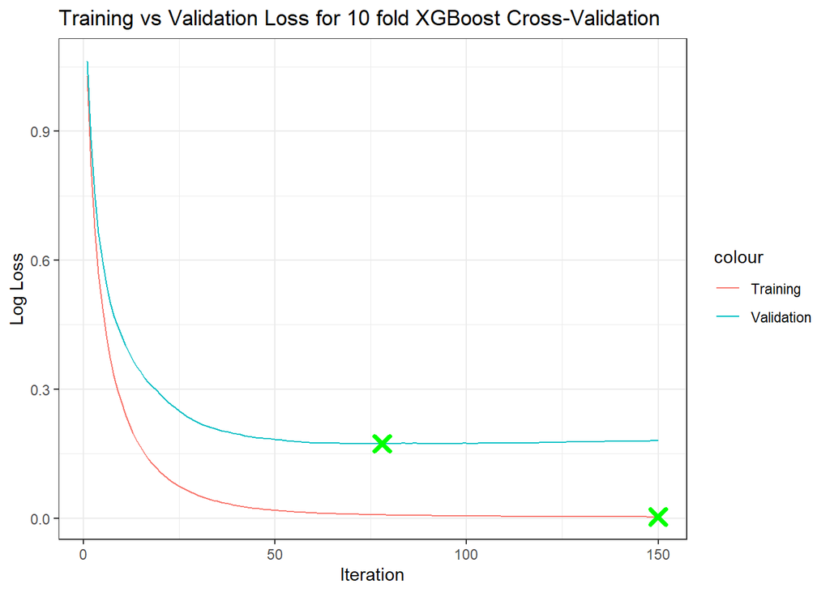

```r
# Accessing the evaluation log
eval_log <- xgb_model$evaluation_log
min_test_loss <- eval_log %>% filter(test_mlogloss_mean == min(test_mlogloss_mean))
min_train_loss <- eval_log %>% filter(train_mlogloss_mean == min(train_mlogloss_mean))

# Plotting train vs test log loss
xgb_plot <- ggplot(data = eval_log, aes(x = iter)) +
  geom_line(aes(y = train_mlogloss_mean, colour = "Training")) +
  geom_line(aes(y = test_mlogloss_mean, colour = "Validation")) +
  geom_point(data = min_test_loss, aes(x = iter, y = test_mlogloss_mean), color = "green", shape = 4, size = 3, stroke = 2) +
  geom_point(data = min_train_loss, aes(x = iter, y = train_mlogloss_mean), color = "green", shape = 4, size = 3, stroke = 2) +
  labs(title = "Training vs Validation Loss for 10 fold XGBoost Cross-Validation", x = "Iteration", y = "Log Loss") +
  theme_bw()

xgb_plot
```

```r
# Finding the iteration with the minimum validation log loss
best_nrounds <- eval_log[[which.min(eval_log$test_mlogloss_mean), "iter"]]
print(best_nrounds)
```

```
## [1] 78
```

```r
xgb_final_model <-
  xgb.train(
    params = xgb_params,
    data = xgb_train,
    nrounds = best_nrounds
  )
```

```r
pred_xgb <- predict(xgb_final_model, newdata = xgb_test)

n_predictions <- length(pred_xgb) / k

xgb_pred_tibble <- matrix(pred_xgb, ncol = k, byrow = TRUE) %>%
  as_tibble()

colnames(xgb_pred_tibble) <- levels(train_data$y)

xgb_pred_tibble <- xgb_pred_tibble %>%
  mutate(predicted_label = colnames(xgb_pred_tibble)[max.col(., ties.method = "first")]) # finds max position in each row, ties.method determines if same value

print(head(xgb_pred_tibble, 5))
```

```
## # A tibble: 5 × 5
##   `ARF/MOSF`   Cancer       Coma `COPD/CHF/Cirrhosis` predicted_label
##        <dbl>    <dbl>      <dbl>                <dbl> <chr>
## 1 0.0113     0.000241 0.000368              0.988     COPD/CHF/Cirrhosis
## 2 0.0143     0.000275 0.000168              0.985     COPD/CHF/Cirrhosis
## 3 0.00000367 1.00     0.00000360            0.0000340 Cancer
## 4 0.000493   0.983    0.0000954             0.0168    Cancer
## 5 0.0617     0.347    0.0266                0.564     COPD/CHF/Cirrhosis
```

The resulting tibble gives the probabilities of each class.

### Test Set Error Rate

```r
y_test <- test_data$y

xgb_error <- mean(y_test != xgb_pred_tibble$predicted_label)

print(xgb_error)
```

```
## [1] 0.06004141
```

#### Confusion Matrix

```r
cm_xgb <- confusionMatrix(reference = factor(y_test), data = factor(xgb_pred_tibble$predicted_label))
cm_xgb
```

```
## Confusion Matrix and Statistics
##
##                     Reference
## Prediction           ARF/MOSF Cancer Coma COPD/CHF/Cirrhosis
##   ARF/MOSF                233      2   14                  4
##   Cancer                    0     61    0                  0
##   Coma                      3      0   18                  0
##   COPD/CHF/Cirrhosis        0      6    0                142
##
## Overall Statistics
##
##                Accuracy : 0.94
##                  95% CI : (0.9149, 0.9594)
##     No Information Rate : 0.4886
##     P-Value [Acc > NIR] : < 2.2e-16
##
##                   Kappa : 0.9048
##
##  Mcnemar's Test P-Value : NA
##
## Statistics by Class:
##
##                      Class: ARF/MOSF Class: Cancer Class: Coma
## Sensitivity                   0.9873        0.8841     0.56250
## Specificity                   0.9190        1.0000     0.99335
## Pos Pred Value                0.9209        1.0000     0.85714
## Neg Pred Value                0.9870        0.9810     0.96970
## Prevalence                    0.4886        0.1429     0.06625
## Detection Rate                0.4824        0.1263     0.03727
## Detection Prevalence          0.5238        0.1263     0.04348
## Balanced Accuracy             0.9532        0.9420     0.77792
##                      Class: COPD/CHF/Cirrhosis
## Sensitivity                             0.9726
## Specificity                             0.9822
## Pos Pred Value                          0.9595
## Neg Pred Value                          0.9881
## Prevalence                              0.3023
## Detection Rate                          0.2940
## Detection Prevalence                    0.3064
## Balanced Accuracy                       0.9774
```

```r
cm_xgb_table <- cm_xgb$table

tpr <- fpr <- tnr <- fnr <- numeric(4)

for (i in 1:4) {
  tp <- cm_xgb_table[i, i]
  fn <- sum(cm_xgb_table[i,]) - tp
  fp <- sum(cm_xgb_table[,i]) - tp
  tn <- sum(cm_xgb_table) - (tp + fn + fp)

  tpr[i] <- tp / (tp + fn)  # True Positive Rate
  fpr[i] <- fp / (fp + tn)  # False Positive Rate
  tnr[i] <- tn / (tn + fp)  # True Negative Rate
  fnr[i] <- fn / (fn + tp)  # False Negative Rate
}

# Print the results
cat("True Positive Rates (TPR):", tpr, "\n",
    "False Positive Rates (FPR):", fpr, "\n",
    "True Negative Rates (TNR):", tnr, "\n",
    "False Negative Rates (FNR):", fnr, "\n")
```

```
## True Positive Rates (TPR): 0.9209486 1 0.8571429 0.9594595
##  False Positive Rates (FPR): 0.01304348 0.01895735 0.03030303 0.0119403
##  True Negative Rates (TNR): 0.9869565 0.9810427 0.969697 0.9880597
##  False Negative Rates (FNR): 0.07905138 0 0.1428571 0.04054054
```

This confusion matrix for an XGBoost model shows an overall accuracy of 94%, indicating strong performance across four classes (ARF/MOSF, Cancer, Coma, and COPD/CHF/cirrhosis). Class-specific performance varies, with high sensitivity and specificity observed particularly for ARF/MOSF (98.73% and 91.90%) and COPD/CHF/cirrhosis (97.26% and 98.22%). However, Coma class has a relatively lower sensitivity at 56.25%, suggesting some challenges in accurately identifying all true cases. This is because of the previously discussed unequal class representation in the dataset. Overall, the model demonstrates effective and reliable predictive capabilities, with particular strengths in specific classes but room for improvement in detecting Coma cases.

# Neural Networks

```r
library(keras)
# library(tensorflow)
```

## Data Preprocessing

```r
nzv <- nearZeroVar(train_data)

train_data_non0var <- train_data[, -nzv]
test_data_non0var <- test_data[, -nzv]

x_train_non0var <- as.matrix(train_data_non0var[, -1])

# excluding columns with near zero variance and scaling, must use same scaling parameters in test set as training set
x_train_non0var_mean <- apply(x_train_non0var, 2, mean)
x_train_non0var_sd <- apply(x_train_non0var, 2, sd)

x_train_non0var_scaled <- scale(x_train_non0var, center = x_train_non0var_mean, scale = x_train_non0var_sd)

input_shape_non0var <- ncol(x_train_non0var)

# same scaling parameters used in training set must be applied for training set (data leakage)
x_test_non0var <- as.matrix(test_data_non0var[, -1])
x_test_non0var_scaled <- scale(x_test_non0var, center = x_train_non0var_mean, scale = x_train_non0var_sd)

y_test_integer <- as.integer(y_test) - 1

y_train <- train_data$y

y_train_integer <- as.integer(train_data$y) - 1
y_test_integer <- as.integer(test_data$y) - 1

y_train_encoded <- to_categorical(y_train_integer)
```

## Neural Network Architecture

The final architecture used has 2 layers with 8 nodes and no dropout layers. The input layer has 38 nodes representing the scaled columns with variance *not* near 0. For $\boldsymbol{X_{train}}$, the dataframe that omit the columns with near 0 variance as well as scaling was used for training. Attempts with the regular training data $X$ were unsuccessful even when scaled. For the testing set, $\boldsymbol{X_{test}}$ was scaled with the same scaling parameters as $\boldsymbol{X_{train}}$ as it would be a procedural error that can lead to inconsistent data representation and misleading results.

Neural Networks are not easily reproducible despite setting an R seed and a TensforFlow seed. Thus we have saved data from a run because otherwise the results change every time the RMarkdown file is knit.

```r
modelnn0 <- keras_model_sequential()
modelnn0 %>%
  layer_dense(units = 8, activation = "relu", # layer 1
              input_shape = input_shape_non0var) %>%
  layer_dense(units = 8, activation = "relu", # layer 1
              input_shape = input_shape_non0var) %>%
  layer_dense(units = 4, activation = "softmax")

summary(modelnn0)
```

```
## Model: "sequential"
## ________________________________________________________________________________
##  Layer (type)                       Output Shape                    Param #
## ================================================================================
##  dense_2 (Dense)                    (None, 8)                       312
##  dense_1 (Dense)                    (None, 8)                       72
##  dense (Dense)                      (None, 4)                       36
## ================================================================================
## Total params: 420 (1.64 KB)
## Trainable params: 420 (1.64 KB)
## Non-trainable params: 0 (0.00 Byte)
## ________________________________________________________________________________
```

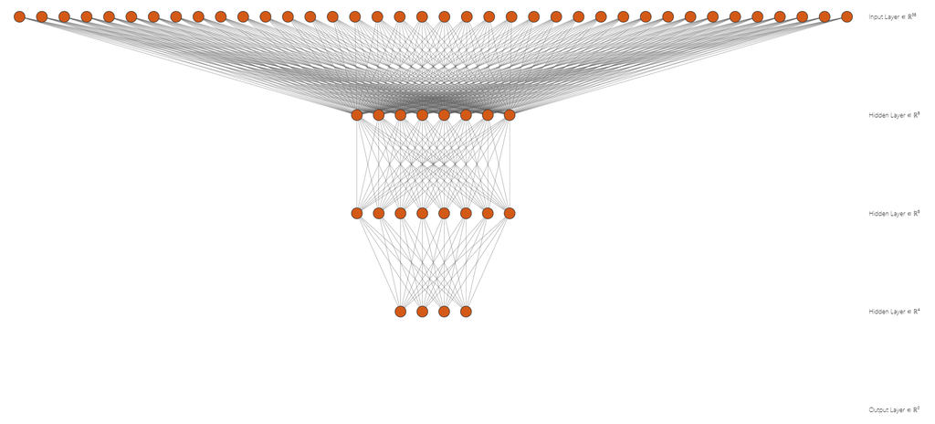

Neural Network Architecture Visualization

```r
library(deepviz)
library(magrittr)

modelnn0 %>% plot_model()
```

[interactive chart not shown]

### Neural Network Training

The loss function was multiclass categorical cross entropy:
$$-\sum_{c=1}^My_{o,c}\log(p_{o,c})$$

```r
set.seed(32)
tensorflow::tf$random$set_seed(32) # need to also set seed for tensorflow for reproducability

early_stop <- callback_early_stopping(
  monitor = "val_loss",
  patience = 50,
  restore_best_weights = TRUE
)

modelnn0 %>%
  compile(
    loss = "categorical_crossentropy",
    optimizer = optimizer_rmsprop(),
    metrics = "accuracy"
  )

history0 <-
  modelnn0 %>%
  fit(
    x_train_non0var_scaled,
    y_train_encoded,
    epochs = 300,
    batch_size = 50,
    validation_split = 0.2,
    callbacks = list(early_stop),
    #class_weight = class_weights,
    verbose = 0
  )
```

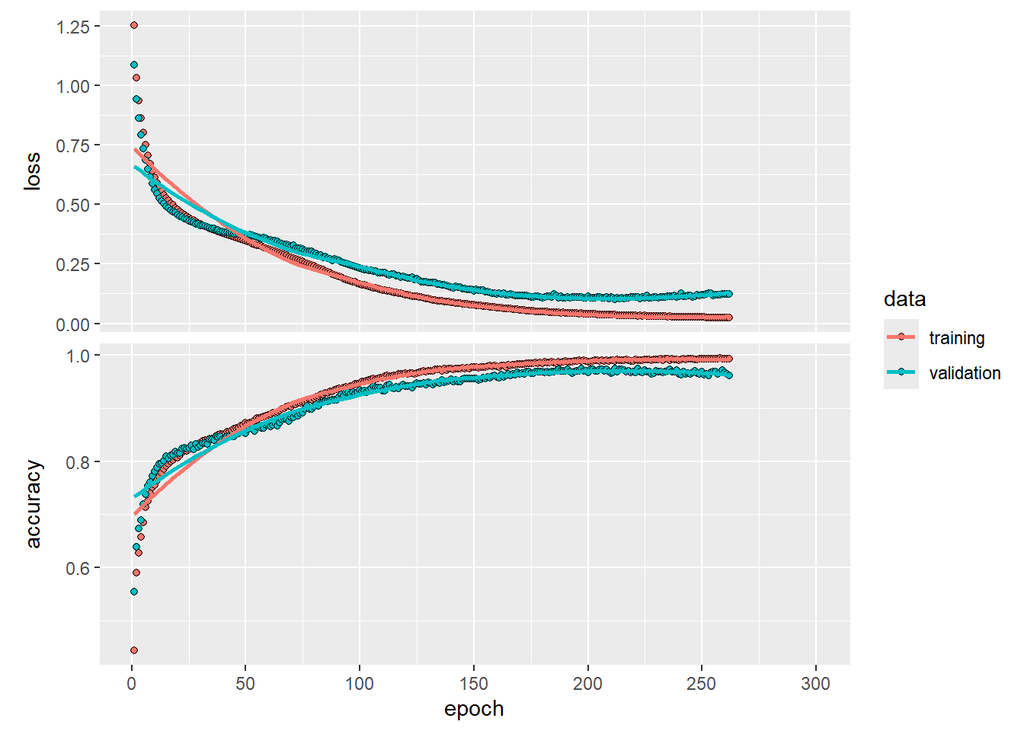

```r
# loading run here
load("neural_network_data.RData")

nn_history_plot <- plot(history)
nn_history_plot
```

```r
history
```

```
##
## Final epoch (plot to see history):
##         loss: 0.02362
##     accuracy: 0.9928
##     val_loss: 0.1224
## val_accuracy: 0.9621
```

The final epoch achieved very impressive accuracy for the training data and validation data.

```r
pred_nn <- predict(modelnn0, x_test_non0var_scaled)
```

```
## 16/16 - 0s - 50ms/epoch - 3ms/step
```

```r
pred_nn_labels <- apply(pred_nn, 1, which.max) - 1 # labels are represented as integers: 0, 1, 2, 3
```

### Neural Network Test Error

```r
y_test <- test_data$y

nn_error0 <- mean(y_test_integer != pred_nn_labels)
```

```r
print(nn_error)
```

```
## [1] 0.04554865
```

#### Confusion Matrix

```r
cm_nn0 <- confusionMatrix(reference = factor(y_test_integer), data = factor(pred_nn_labels))
cm_nn
```

```
## Confusion Matrix and Statistics
##
##           Reference
## Prediction   0   1   2   3
##          0 229   1   6   4
##          1   1  66   0   1
##          2   4   1  25   0
##          3   2   1   1 141
##
## Overall Statistics
##
##                Accuracy : 0.9545
##                  95% CI : (0.9318, 0.9712)
##     No Information Rate : 0.4886
##     P-Value [Acc > NIR] : <2e-16
##
##                   Kappa : 0.9291
##
##  Mcnemar's Test P-Value : 0.8004
##
## Statistics by Class:
##
##                      Class: 0 Class: 1 Class: 2 Class: 3
## Sensitivity            0.9703   0.9565  0.78125   0.9658
## Specificity            0.9555   0.9952  0.98891   0.9881
## Pos Pred Value         0.9542   0.9706  0.83333   0.9724
## Neg Pred Value         0.9712   0.9928  0.98455   0.9852
## Prevalence             0.4886   0.1429  0.06625   0.3023
## Detection Rate         0.4741   0.1366  0.05176   0.2919
## Detection Prevalence   0.4969   0.1408  0.06211   0.3002
## Balanced Accuracy      0.9629   0.9758  0.88508   0.9769
```

```r
cm_nn_table <- cm_nn$table

tpr <- fpr <- tnr <- fnr <- numeric(4)

for (i in 1:4) {
  tp <- cm_nn_table[i, i]
  fn <- sum(cm_nn_table[i,]) - tp
  fp <- sum(cm_nn_table[,i]) - tp
  tn <- sum(cm_nn_table) - (tp + fn + fp)

  tpr[i] <- tp / (tp + fn)  # True Positive Rate
  fpr[i] <- fp / (fp + tn)  # False Positive Rate
  tnr[i] <- tn / (tn + fp)  # True Negative Rate
  fnr[i] <- fn / (fn + tp)  # False Negative Rate
}

# Print the results
cat("True Positive Rates (TPR):", tpr, "\n",
    "False Positive Rates (FPR):", fpr, "\n",
    "True Negative Rates (TNR):", tnr, "\n",
    "False Negative Rates (FNR):", fnr, "\n")
```

```
## True Positive Rates (TPR): 0.9541667 0.9705882 0.8333333 0.9724138
##  False Positive Rates (FPR): 0.02880658 0.007228916 0.01545254 0.0147929
##  True Negative Rates (TNR): 0.9711934 0.9927711 0.9845475 0.9852071
##  False Negative Rates (FNR): 0.04583333 0.02941176 0.1666667 0.02758621
```

This confusion matrix reveals that the neural network performs quite well overall, with an accuracy of 95.45%. Sensitivity (true positive rate) and specificity (true negative rate) are high for most classes, indicating the model’s proficiency in correctly identifying true positives and true negatives. Class 0 (ARF/MOSF) and class 3 (COPD/CHF/Cirrhosis) show particularly high performance metrics, whereas class 2 (Coma) has a slightly lower sensitivity (78.13%) and positive predictive value (83.33%), indicating some challenges in correctly predicting this class. This is most likely due to the smaller amount of observations pertaining to class 2 (Coma) than the other classes as explained previously.

# Conclusions

```r
model_names <- c("cm_bag", "cm_boost", "cm_e_mlogit", "cm_knn", "cm_lda",
                 "cm_mlogit", "cm_nb", "cm_nn", "cm_qda", "cm_raw_lda",
                 "cm_raw_qda", "cm_rf", "cm_trans_lda", "cm_xgb")

results <- data.frame(Model = character(), Accuracy = numeric(),
                      Lower_CI = numeric(), Upper_CI = numeric(), stringsAsFactors = FALSE)


for (model in model_names) {
  cm_table <- get(paste(model, "_table", sep = ""))
  acc <- sum(diag(cm_table)) / sum(cm_table)
  se <- sqrt(acc * (1 - acc) / sum(cm_table))
  ci_lower <- acc - 1.96 * se
  ci_upper <- acc + 1.96 * se


  results <- rbind(results, data.frame(Model = sub("cm_", "", model), Accuracy = acc,
                                       Lower_CI = ci_lower, Upper_CI = ci_upper))
}

results$Model <- factor(results$Model)

results <- results[order(-results$Accuracy), ]

results$Model <- factor(results$Model, levels = results$Model)

print(results)
```

```
##        Model  Accuracy  Lower_CI  Upper_CI
## 2      boost 0.9565217 0.9383345 0.9747089
## 8         nn 0.9544513 0.9358563 0.9730464
## 14       xgb 0.9399586 0.9187719 0.9611452
## 6     mlogit 0.9047619 0.8785828 0.9309410
## 3   e_mlogit 0.8861284 0.8577989 0.9144578
## 10   raw_lda 0.8654244 0.8349889 0.8958599
## 13 trans_lda 0.8447205 0.8124210 0.8770200
## 1        bag 0.8385093 0.8056915 0.8713272
## 5        lda 0.8385093 0.8056915 0.8713272
## 12        rf 0.7929607 0.7568251 0.8290962
## 9        qda 0.6749482 0.6331754 0.7167211
## 11   raw_qda 0.6749482 0.6331754 0.7167211
## 4        knn 0.6107660 0.5672825 0.6542496
## 7         nb 0.3478261 0.3053499 0.3903023
```

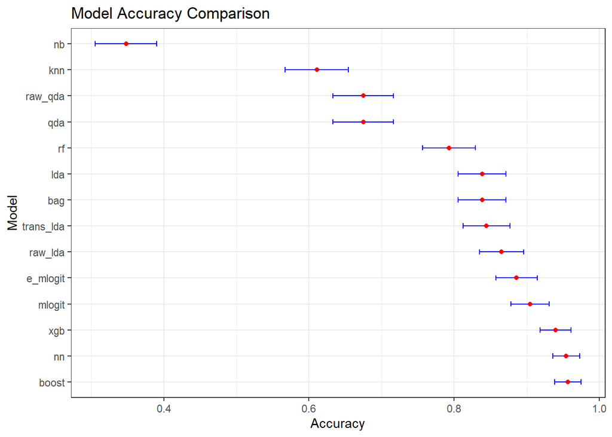

```r
# plotting the accuracies with confidence intervals
results_plot <- ggplot(results, aes(x = Model, y = Accuracy)) +
  geom_errorbar(aes(ymin = Lower_CI, ymax = Upper_CI), width = 0.2, color = "blue") +
  geom_point(color = "red") +
  coord_flip() +
  theme_bw() +
  labs(title = "Model Accuracy Comparison", x = "Model", y = "Accuracy")

results_plot
```